# Airbnb Pricing Predictions

Airbnb is a hospitality company that runs an online marketplace for renting and leasing short-term lodging. It is interested in developing a pricing service for its users that will compute a recommended price based on the features of a listing. As a consultant working for a data analytics company, we are approached by Airbnb to develop a model for predicting nightly prices of Airbnb listings based on state-of-art techniques from statistical learning. The focus of your analytics team is on the properties in London, UK.

We are provided with a [dataset](https://www.kaggle.com/t/28cb00294fe94927ac801164794b75dd) containing detailed information on a number of existing Airbnb listings in London. As part of the contract, we are asked to write a report and our work will bed evaluated with the test set RMSE. The workflow is as follows:

Data: Airbnb Listings  
Data Cleansing  
Exploratory Data Analysis  
Data transformation  
Model Training  
Prediction and Submission

```python
# Packages
import pandas as pd
import numpy as np
import math
import seaborn as sns
import matplotlib.pyplot as plt
import statsmodels.api as sm
import xgboost as xgb
import warnings
warnings.filterwarnings("ignore")
pd.options.display.max_columns = None

from scipy import stats, special
from sklearn.pipeline import Pipeline
from sklearn.linear_model import LinearRegression, LassoCV, RidgeCV, ElasticNetCV
from sklearn.preprocessing import StandardScaler
from sklearn.neighbors import KNeighborsRegressor
from sklearn.tree import DecisionTreeRegressor
from sklearn.ensemble import RandomForestRegressor, BaggingRegressor
from sklearn.model_selection import cross_val_predict
from sklearn.model_selection import cross_val_score
from sklearn.model_selection import GridSearchCV, RandomizedSearchCV
from sklearn.metrics import mean_squared_error, r2_score,  mean_absolute_error
from scipy.stats import skew
from mlxtend.regressor import StackingCVRegressor
```

# Data: Airbnb Listings

```python
# Missing values, print as a table for report
df_train = pd.read_csv('train.csv')
df_test = pd.read_csv('test.csv')
df_train['split'] = 1
df_test['split'] = 2
df_test['price'] = 0
df_concat = pd.concat([df_train,df_test])
df_concat.head()
```

|  | Id | price | experiences_offered | host_response_time | host_response_rate | host_is_superhost | host_listings_count | host_identity_verified | latitude | longitude | property_type | room_type | accommodates | bathrooms | bedrooms | beds | bed_type | security_deposit | cleaning_fee | guests_included | extra_people | minimum_nights | maximum_nights | number_of_reviews | review_scores_rating | review_scores_accuracy | review_scores_cleanliness | review_scores_checkin | review_scores_communication | … |
| --- | --- | --- | --- | --- | --- | --- | --- | --- | --- | --- | --- | --- | --- | --- | --- | --- | --- | --- | --- | --- | --- | --- | --- | --- | --- | --- | --- | --- | --- | --- |
| 0 | 1000 | 90 | none | within an hour | 1.00 | f | 11.0 | f | 51.547349 | -0.219334 | Hostel | Private room | 4 | 4.0 | 1.0 | 4.0 | Real Bed | NaN | NaN | 4 | 0 | 1 | 1125 | 6 | 80.0 | 9.0 | 8.0 | 9.0 | 9.0 | … |
| 1 | 1001 | 120 | none | NaN | NaN | f | 1.0 | f | 51.550826 | -0.208280 | Apartment | Entire home/apt | 4 | 2.0 | 2.0 | 2.0 | Real Bed | NaN | NaN | 1 | 0 | 1 | 1125 | 0 | NaN | NaN | NaN | NaN | NaN | … |
| 2 | 1002 | 100 | none | NaN | NaN | t | 1.0 | f | 51.489698 | -0.194910 | Apartment | Entire home/apt | 2 | 1.0 | 0.0 | 0.0 | Real Bed | 500.0 | 25.0 | 1 | 9 | 2 | 1125 | 7 | 97.0 | 10.0 | 10.0 | 10.0 | 10.0 | … |
| 3 | 1003 | 89 | none | within an hour | 1.00 | f | 18.0 | f | 51.518718 | -0.125574 | Apartment | Private room | 3 | 1.0 | 0.0 | 2.0 | Real Bed | 80.0 | 29.0 | 1 | 15 | 1 | 1125 | 45 | 90.0 | 9.0 | 9.0 | 10.0 | 10.0 | … |
| 4 | 1004 | 300 | none | within a day | 0.88 | f | 25.0 | t | 51.515499 | -0.154633 | Condominium | Entire home/apt | 5 | 2.0 | 3.0 | 3.0 | Real Bed | 300.0 | 150.0 | 1 | 0 | 7 | 1125 | 0 | NaN | NaN | NaN | NaN | NaN | … |

```python
Missing_values = df_concat.isna().sum().sort_values(ascending=False, inplace=False)
dict_Missing_values = {'Variables':Missing_values.index,'Counts':Missing_values.values}
df_Missing_values = pd.DataFrame(dict_Missing_values)
df_Missing_values.index = np.arange(1, len(df_Missing_values)+1)
df_Missing_values
```

|  | Variables | Counts |
| --- | --- | --- |
| 1 | security_deposit | 642 |
| 2 | host_response_time | 617 |
| 3 | host_response_rate | 617 |
| 4 | review_scores_value | 518 |
| 5 | review_scores_location | 517 |
| 6 | review_scores_accuracy | 516 |
| 7 | review_scores_communication | 516 |
| 8 | review_scores_checkin | 516 |
| 9 | review_scores_cleanliness | 516 |
| 10 | review_scores_rating | 515 |
| 11 | reviews_per_month | 479 |
| 12 | cleaning_fee | 472 |
| 13 | bathrooms | 6 |
| 14 | beds | 3 |
| 15 | bedrooms | 2 |
| 16 | host_is_superhost | 1 |
| 17 | host_listings_count | 1 |
| 18 | host_identity_verified | 1 |
| 19 | room_type | 0 |
| 20 | latitude | 0 |
| 21 | longitude | 0 |
| 22 | experiences_offered | 0 |
| 23 | price | 0 |
| 24 | property_type | 0 |
| 25 | split | 0 |
| 26 | accommodates | 0 |
| 27 | bed_type | 0 |
| 28 | guests_included | 0 |
| 29 | extra_people | 0 |
| 30 | minimum_nights | 0 |
| 31 | maximum_nights | 0 |
| 32 | number_of_reviews | 0 |
| 33 | instant_bookable | 0 |
| 34 | cancellation_policy | 0 |
| 35 | require_guest_profile_picture | 0 |
| 36 | require_guest_phone_verification | 0 |
| 37 | Id | 0 |

2000 observations, 35 features,

```python
df_concat.dtypes
```

```
Id                                    int64
price                                 int64
experiences_offered                  object
host_response_time                   object
host_response_rate                  float64
host_is_superhost                    object
host_listings_count                 float64
host_identity_verified               object
latitude                            float64
longitude                           float64
property_type                        object
room_type                            object
accommodates                          int64
bathrooms                           float64
bedrooms                            float64
beds                                float64
bed_type                             object
security_deposit                    float64
cleaning_fee                        float64
guests_included                       int64
extra_people                          int64
minimum_nights                        int64
maximum_nights                        int64
number_of_reviews                     int64
review_scores_rating                float64
review_scores_accuracy              float64
review_scores_cleanliness           float64
review_scores_checkin               float64
review_scores_communication         float64
review_scores_location              float64
review_scores_value                 float64
instant_bookable                     object
cancellation_policy                  object
require_guest_profile_picture        object
require_guest_phone_verification     object
reviews_per_month                   float64
split                                 int64
dtype: object
```

# Data Cleansing

Fill missing values according to practical meanings and distributions:

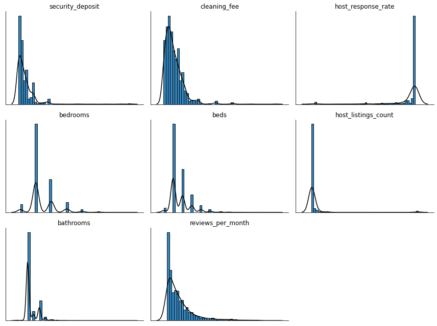

```python
from statlearning01 import plot_histograms
float_missing = ['security_deposit', 'cleaning_fee','host_response_rate','bedrooms','beds','host_listings_count','bathrooms','reviews_per_month']
plot_histograms(df_concat[float_missing])
plt.show()
```

```python
object_missing = ['host_is_superhost', 'host_identity_verified', 'host_response_time']
df_concat[object_missing].head(10)
```

|  | host_is_superhost | host_identity_verified | host_response_time |
| --- | --- | --- | --- |
| 0 | f | f | within an hour |
| 1 | f | f | NaN |
| 2 | t | f | NaN |
| 3 | f | f | within an hour |
| 4 | f | t | within a day |
| 5 | f | t | within an hour |
| 6 | f | t | within an hour |
| 7 | f | f | within an hour |
| 8 | f | t | within a day |
| 9 | f | f | NaN |

```python
# Deal with missing values
for i in ['security_deposit', 'cleaning_fee']:
    df_concat[i] = df_concat[i].apply(lambda x: 0 if pd.isna(x) else x)
for i in ['host_is_superhost', 'host_identity_verified']:
    df_concat[i] = df_concat[i].apply(lambda x: 'f' if pd.isna(x) else x)
for i in ['host_response_rate','bedrooms','beds']:
    df_concat[i] = df_concat[i].apply(lambda x: float(df_concat[i].mean()) if pd.isna(x) else x)
for i in ['host_listings_count','bathrooms']:
    df_concat[i] = df_concat[i].apply(lambda x: float(df_concat[i].mode()) if pd.isna(x) else x)
for i in ['reviews_per_month']:
    df_concat[i] = df_concat[i].apply(lambda x: float(df_concat[i].median()) if pd.isna(x) else x)
for i in ['host_response_time']:
        df_concat[i] = df_concat[i].apply(lambda x: 'no_response' if pd.isna(x) else x)
```

Drop ID column since it has nothing to do with price:

```python
df_concat = df_concat.drop(['Id'],axis=1)
```

Deal with categorical varaibles and get dummies:

```python
  # experience_offered
df_concat['experiences_offered']=df_concat['experiences_offered'].replace(['social','family','business','romantic'],'Other')
  # property type
df_concat['property_type']=df_concat['property_type'].replace(['Villa','Cottage','Treehouse','Loft','Condominium','Bed and breakfast','Other','Boutique hotel','Guesthouse','Hotel','Hostel','Guest suite','Farm stay','Aparthotel','Boat'],'Other')
  # cancellation_policy
df_concat=df_concat.replace({'flexible':5,'moderate':4,'strict_14_with_grace_period':3,'super_strict_60':1,'super_strict_30':2})
  # scores
def scores (i):
    if np.isnan(i)==True:
        return 'no_response'
    if i <= 3.0:
        return 'bad'
    elif i <=7:
        return 'moderate'
    elif i <=10:
        return'good'
df_concat['review_scores_accuracy'] = df_concat['review_scores_accuracy'].apply(scores)
df_concat['review_scores_cleanliness'] = df_concat['review_scores_cleanliness'].apply(scores)
df_concat['review_scores_checkin'] = df_concat['review_scores_checkin'].apply(scores)
df_concat['review_scores_location'] = df_concat['review_scores_location'].apply(scores)
df_concat['review_scores_value'] = df_concat['review_scores_value'].apply(scores)
df_concat['review_scores_communication'] = df_concat['review_scores_communication'].apply(scores)
def scores_rating (i):
    if np.isnan(i)==True:
        return 'no_response'
    if i <= 30.0:
        return 'bad'
    elif i <= 70.0:
        return 'moderate'
    elif i <= 100.0:
        return'good'
df_concat['review_scores_rating'] = df_concat['review_scores_rating'].apply(scores_rating)
  # bool to int
df_concat['host_identity_verified'] = df_concat['host_identity_verified'].map({'f':0,'t':1})
df_concat['host_is_superhost'] = df_concat['host_is_superhost'].map({'f':0,'t':1})
df_concat['require_guest_phone_verification'] = df_concat['require_guest_phone_verification'].map({'f':0,'t':1})
df_concat['require_guest_profile_picture'] = df_concat['require_guest_profile_picture'].map({'f':0,'t':1})
df_concat['instant_bookable'] = df_concat['instant_bookable'].map({'f':0,'t':1})
  # get dummies
cat_col=['experiences_offered','bed_type','host_response_time','property_type','review_scores_accuracy','review_scores_checkin','review_scores_cleanliness','review_scores_communication','review_scores_location','room_type','review_scores_rating','review_scores_value','cancellation_policy']
df_concat=pd.get_dummies(df_concat,columns=cat_col,drop_first=True)
```

```python
train = df_concat.loc[df_concat['split'] == 1]
test = df_concat.loc[df_concat['split'] == 2]
```

# Exploratory Data Analysis

Visualizing the location of the houses based on latitude and longitude:

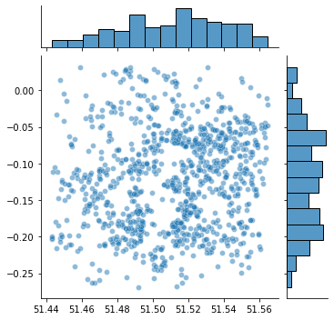

```python
plt.figure(figsize=(5,5))
sns.jointplot(x=train.latitude.values,y=train.longitude.values,size=5,alpha=0.5)
plt.ylabel('longitude',fontsize=3)
plt.xlabel('latitude',fontsize=3)
sns.despine()
plt.show()
```

Cluster into 10 groups:

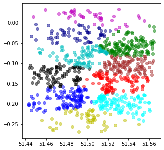

```python
from sklearn.cluster import KMeans
geo_df=train[['latitude', 'longitude']]
kmeans = KMeans(n_clusters=10).fit(geo_df[['latitude', 'longitude']])
geo_df['cluster_n'] = kmeans.labels_

fig = plt.figure(figsize=(5, 5))
x = np.array(geo_df['latitude'])
y = np.array(geo_df['longitude'])

colors = ['b', 'g', 'r', 'c', 'm', 'y', 'k', 'aqua', 'brown', 'darkblue']
#print color
for i,c in enumerate(geo_df['cluster_n']):
    plt.scatter(x[i], y[i], c=colors[c], alpha=0.5)
plt.show()
```

Feature Engineering:

```python
# Location: to calculate the distance from LondonEye
from math import *
def Distance(Lat_A, Lng_A, Lat_B, Lng_B):
    ra = 6378.140  # equatorial radius in km
    rb = 6356.755  # polar radius (km)
    flatten = (ra - rb) / ra  # oblateness
    rad_lat_A = radians(Lat_A)
    rad_lng_A = radians(Lng_A)
    rad_lat_B = radians(Lat_B)
    rad_lng_B = radians(Lng_B)
    pA = atan(rb / ra * tan(rad_lat_A))
    pB = atan(rb / ra * tan(rad_lat_B))
    xx = acos(sin(pA) * sin(pB) + cos(pA) * cos(pB) * cos(rad_lng_A - rad_lng_B))
    c1 = (sin(xx) - xx) * (sin(pA) + sin(pB)) ** 2 / cos(xx / 2) ** 2
    c2 = (sin(xx) + xx) * (sin(pA) - sin(pB)) ** 2 / sin(xx / 2) ** 2
    dr = flatten / 8 * (c1 - c2)
    distance = ra * (xx + dr)
    return distance
  # Lat&lng of LondonEye
Lat_LondonEye = 51.507222
Lng_LondonEye = -0.1194
pd.to_numeric(train.loc[0:,'longitude'])
pd.to_numeric(train.loc[0:,'latitude'])
  # A new column = distance
train.loc[0:,'distance_Eye'] = 0
for i in range(0,999):
    train.loc[i,'distance_Eye'] = Distance(train.loc[i,'latitude'],train.loc[i,'longitude'],Lat_LondonEye,Lng_LondonEye)
pd.to_numeric(df_test.loc[0:,'longitude'])
pd.to_numeric(df_test.loc[0:,'latitude'])
test.loc[0:,'distance_Eye'] = 0
for i in range(0,999):
    test.loc[i,'distance_Eye'] = Distance(test.loc[i,'latitude'],test.loc[i,'longitude'],Lat_LondonEye,Lng_LondonEye)
```

```python
train.head(10)
```

|  | price | host_response_rate | host_is_superhost | host_listings_count | host_identity_verified | latitude | longitude | accommodates | bathrooms | bedrooms | beds | security_deposit | cleaning_fee | guests_included | extra_people | minimum_nights | maximum_nights | number_of_reviews | instant_bookable | require_guest_profile_picture | require_guest_phone_verification | reviews_per_month | split | experiences_offered_none | bed_type_Couch | bed_type_Futon | bed_type_Pull-out Sofa | bed_type_Real Bed | host_response_time_no_response | … |
| --- | --- | --- | --- | --- | --- | --- | --- | --- | --- | --- | --- | --- | --- | --- | --- | --- | --- | --- | --- | --- | --- | --- | --- | --- | --- | --- | --- | --- | --- | --- |
| 0 | 90 | 1.000000 | 0 | 11.0 | 0 | 51.547349 | -0.219334 | 4 | 4.0 | 1.0 | 4.0 | 0.0 | 0.0 | 4 | 0 | 1 | 1125 | 6 | 1 | 0 | 0 | 0.76 | 1 | 1 | 0 | 0 | 0 | 1 | 0 | … |
| 1 | 120 | 0.935423 | 0 | 1.0 | 0 | 51.550826 | -0.208280 | 4 | 2.0 | 2.0 | 2.0 | 0.0 | 0.0 | 1 | 0 | 1 | 1125 | 0 | 1 | 0 | 0 | 0.73 | 1 | 1 | 0 | 0 | 0 | 1 | 1 | … |
| 2 | 100 | 0.935423 | 1 | 1.0 | 0 | 51.489698 | -0.194910 | 2 | 1.0 | 0.0 | 0.0 | 500.0 | 25.0 | 1 | 9 | 2 | 1125 | 7 | 0 | 0 | 0 | 1.15 | 1 | 1 | 0 | 0 | 0 | 1 | 1 | … |
| 3 | 89 | 1.000000 | 0 | 18.0 | 0 | 51.518718 | -0.125574 | 3 | 1.0 | 0.0 | 2.0 | 80.0 | 29.0 | 1 | 15 | 1 | 1125 | 45 | 0 | 0 | 0 | 2.26 | 1 | 1 | 0 | 0 | 0 | 1 | 0 | … |
| 4 | 300 | 0.880000 | 0 | 25.0 | 1 | 51.515499 | -0.154633 | 5 | 2.0 | 3.0 | 3.0 | 300.0 | 150.0 | 1 | 0 | 7 | 1125 | 0 | 0 | 0 | 0 | 0.73 | 1 | 1 | 0 | 0 | 0 | 1 | 0 | … |
| 5 | 90 | 1.000000 | 0 | 7.0 | 1 | 51.489869 | -0.228389 | 6 | 1.5 | 3.0 | 3.0 | 200.0 | 0.0 | 1 | 10 | 3 | 1124 | 0 | 1 | 0 | 0 | 0.73 | 1 | 1 | 0 | 0 | 0 | 1 | 0 | … |
| 6 | 40 | 1.000000 | 0 | 2.0 | 1 | 51.524937 | -0.071451 | 1 | 1.0 | 1.0 | 1.0 | 0.0 | 10.0 | 1 | 0 | 2 | 1125 | 0 | 1 | 0 | 0 | 0.73 | 1 | 1 | 0 | 0 | 0 | 1 | 0 | … |
| 7 | 327 | 0.960000 | 0 | 1277.0 | 0 | 51.550765 | -0.196139 | 8 | 3.5 | 4.0 | 4.0 | 495.0 | 300.0 | 8 | 0 | 3 | 1125 | 1 | 1 | 0 | 0 | 0.05 | 1 | 1 | 0 | 0 | 0 | 1 | 0 | … |
| 8 | 90 | 1.000000 | 0 | 1.0 | 1 | 51.480024 | -0.182333 | 2 | 1.0 | 1.0 | 1.0 | 200.0 | 35.0 | 1 | 0 | 2 | 14 | 43 | 0 | 0 | 0 | 0.96 | 1 | 1 | 0 | 0 | 0 | 1 | 0 | … |
| 9 | 65 | 0.935423 | 0 | 1.0 | 0 | 51.540791 | -0.144308 | 2 | 1.0 | 1.0 | 1.0 | 0.0 | 0.0 | 1 | 0 | 2 | 9 | 0 | 0 | 0 | 0 | 0.73 | 1 | 1 | 0 | 0 | 0 | 1 | 1 | … |

Feature Selection:

```python
# Corr with price
corr = train.corr().sort_values(['price'],axis=0, ascending = False)
price_corr = corr.loc[:,'price'].dropna()
Price_corr = {'Variables':price_corr.index,'Price_corr':price_corr.values}
Price_corr = pd.DataFrame(Price_corr).drop(0)
Price_corr
```

|  | Variables | Price_corr |
| --- | --- | --- |
| 1 | accommodates | 0.649212 |
| 2 | beds | 0.531520 |
| 3 | bedrooms | 0.529675 |
| 4 | cleaning_fee | 0.520284 |
| 5 | bathrooms | 0.473372 |
| ... | ... | ... |
| 57 | longitude | -0.169498 |
| 58 | distance_Eye | -0.198601 |
| 59 | host_response_time_no_response | -0.214364 |
| 60 | cancellation_policy_5 | -0.236698 |
| 61 | room_type_Private room | -0.538836 |

61 rows × 2 columns

```python
# Variable selection according to correlation
corr_selected = price_corr.loc[(price_corr>=0.1)|(price_corr<=-0.1)]
corr_selected
```

```
price                                1.000000
accommodates                         0.649212
beds                                 0.531520
bedrooms                             0.529675
cleaning_fee                         0.520284
bathrooms                            0.473372
guests_included                      0.352264
security_deposit                     0.299492
host_listings_count                  0.236387
cancellation_policy_3                0.234128
host_response_time_within an hour    0.182686
property_type_Serviced apartment     0.179138
maximum_nights                       0.161332
review_scores_communication_good    -0.107383
review_scores_accuracy_good         -0.109272
longitude                           -0.169498
distance_Eye                        -0.198601
host_response_time_no_response      -0.214364
cancellation_policy_5               -0.236698
room_type_Private room              -0.538836
Name: price, dtype: float64
```

```python
corr_selected.index
```

```
Index(['price', 'accommodates', 'beds', 'bedrooms', 'cleaning_fee',
       'bathrooms', 'guests_included', 'security_deposit',
       'host_listings_count', 'cancellation_policy_3',
       'host_response_time_within an hour', 'property_type_Serviced apartment',
       'maximum_nights', 'review_scores_communication_good',
       'review_scores_accuracy_good', 'longitude', 'distance_Eye',
       'host_response_time_no_response', 'cancellation_policy_5',
       'room_type_Private room'],
      dtype='object')
```

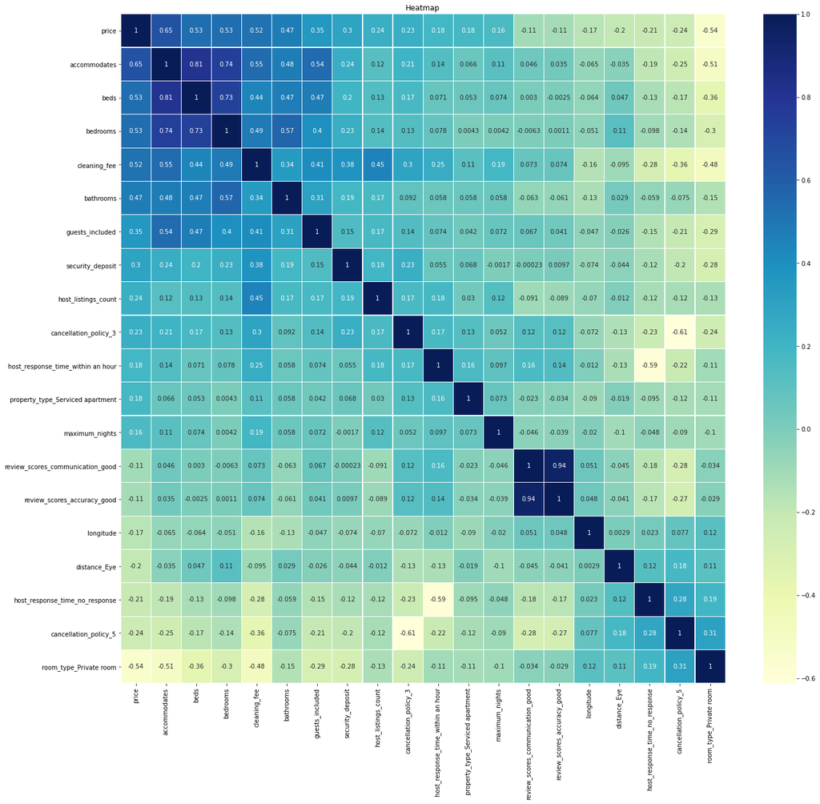

```python
# Check multicollinearity
colormap = plt.cm.RdBu
plt.figure(figsize = (22,20))
sns.heatmap(train.loc[:,corr_selected.index].astype(float).corr(),linewidths = 0.2,annot = True,cmap="YlGnBu")
plt.title('Heatmap')
plt.show()
```

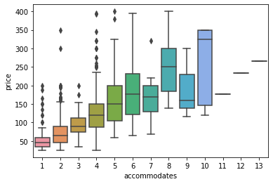

```python
sns.boxplot(x='accommodates',y='price',data=train)
```

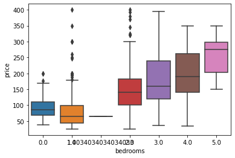

```python
sns.boxplot(x='bedrooms',y='price',data=train)
```

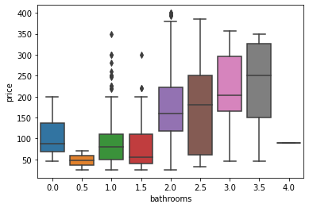

```python
sns.boxplot(x='bathrooms',y='price',data=train)
```

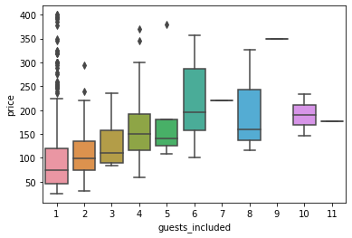

```python
sns.boxplot(x='guests_included',y='price',data=train)
```

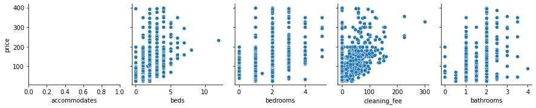

```python
sns.pairplot(train,
            y_vars=['price'],
            x_vars=['accommodates', 'beds', 'bedrooms', 'cleaning_fee','bathrooms'])
```

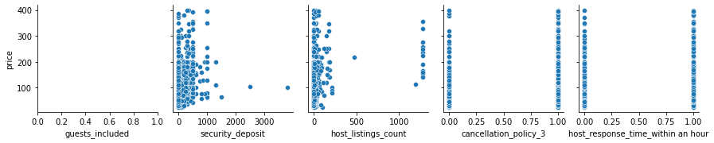

```python
sns.pairplot(train,
            y_vars=['price'],
            x_vars=['guests_included', 'security_deposit','host_listings_count','cancellation_policy_3','host_response_time_within an hour'])
```

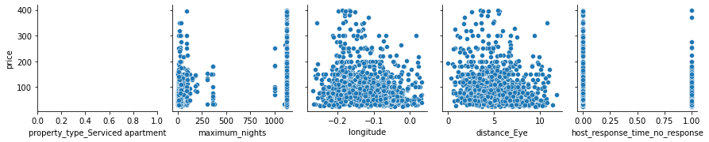

```python
sns.pairplot(train,
            y_vars=['price'],
            x_vars=['property_type_Serviced apartment','maximum_nights', 'longitude', 'distance_Eye','host_response_time_no_response'])
```

Feature Extraction:

```python
corr_selected_train = train.loc[:,corr_selected.index]
corr_selected_train['beds_per_room'] = corr_selected_train['beds']/corr_selected_train['bedrooms']
multi_selected_train = corr_selected_train.drop(columns=['beds','bedrooms','cancellation_policy_3','host_response_time_within an hour'])
corr_selected_test = test.loc[:,corr_selected.index]
corr_selected_test['beds_per_room'] = corr_selected_test['beds']/corr_selected_test['bedrooms']
multi_selected_test = corr_selected_test.drop(columns=['beds','bedrooms','cancellation_policy_3','host_response_time_within an hour'])
```

```python
multi_selected_train.head(10)
```

|  | price | accommodates | cleaning_fee | bathrooms | guests_included | security_deposit | host_listings_count | property_type_Serviced apartment | maximum_nights | review_scores_communication_good | review_scores_accuracy_good | longitude | distance_Eye | host_response_time_no_response | cancellation_policy_5 | room_type_Private room | beds_per_room |
| --- | --- | --- | --- | --- | --- | --- | --- | --- | --- | --- | --- | --- | --- | --- | --- | --- | --- |
| 0 | 90 | 4 | 0.0 | 4.0 | 4 | 0.0 | 11.0 | 0 | 1125 | 1 | 1 | -0.219334 | 8.248025 | 0 | 1 | 1 | 4.0 |
| 1 | 120 | 4 | 0.0 | 2.0 | 1 | 0.0 | 1.0 | 0 | 1125 | 0 | 0 | -0.208280 | 7.847175 | 1 | 1 | 0 | 1.0 |
| 2 | 100 | 2 | 25.0 | 1.0 | 1 | 500.0 | 1.0 | 0 | 1125 | 1 | 1 | -0.194910 | 5.594386 | 1 | 0 | 0 | NaN |
| 3 | 89 | 3 | 29.0 | 1.0 | 1 | 80.0 | 18.0 | 0 | 1125 | 1 | 1 | -0.125574 | 1.348929 | 0 | 0 | 1 | inf |
| 4 | 300 | 5 | 150.0 | 2.0 | 1 | 300.0 | 25.0 | 0 | 1125 | 0 | 0 | -0.154633 | 2.613628 | 0 | 1 | 0 | 1.0 |
| 5 | 90 | 6 | 0.0 | 1.5 | 1 | 200.0 | 7.0 | 0 | 1124 | 0 | 0 | -0.228389 | 7.810827 | 0 | 0 | 0 | 1.0 |
| 6 | 40 | 1 | 10.0 | 1.0 | 1 | 0.0 | 2.0 | 0 | 1125 | 0 | 0 | -0.071451 | 3.868221 | 0 | 1 | 1 | 1.0 |
| 7 | 327 | 8 | 300.0 | 3.5 | 8 | 495.0 | 1277.0 | 0 | 1125 | 1 | 1 | -0.196139 | 7.199257 | 0 | 0 | 0 | 1.0 |
| 8 | 90 | 2 | 35.0 | 1.0 | 1 | 200.0 | 1.0 | 0 | 14 | 1 | 1 | -0.182333 | 5.315973 | 0 | 0 | 0 | 1.0 |
| 9 | 65 | 2 | 0.0 | 1.0 | 1 | 0.0 | 1.0 | 0 | 9 | 0 | 0 | -0.144308 | 4.115479 | 1 | 1 | 1 | 1.0 |

```python
for i in ['beds_per_room']:
    multi_selected_train[i] = multi_selected_train[i].apply(lambda x: float(multi_selected_train[i].mean()) if pd.isna(x) else x)
inf = np.isinf(multi_selected_train)
multi_selected_train[inf]=1
for i in ['beds_per_room']:
    multi_selected_test[i] = multi_selected_test[i].apply(lambda x: float(multi_selected_test[i].mean()) if pd.isna(x) else x)
inf = np.isinf(multi_selected_test)
multi_selected_test[inf]=1
```

```python
multi_selected_train.head(10)
```

|  | price | accommodates | cleaning_fee | bathrooms | guests_included | security_deposit | host_listings_count | property_type_Serviced apartment | maximum_nights | review_scores_communication_good | review_scores_accuracy_good | longitude | distance_Eye | host_response_time_no_response | cancellation_policy_5 | room_type_Private room | beds_per_room |
| --- | --- | --- | --- | --- | --- | --- | --- | --- | --- | --- | --- | --- | --- | --- | --- | --- | --- |
| 0 | 90 | 4 | 0.0 | 4.0 | 4 | 0.0 | 11.0 | 0 | 1125 | 1 | 1 | -0.219334 | 8.248025 | 0 | 1 | 1 | 4.0 |
| 1 | 120 | 4 | 0.0 | 2.0 | 1 | 0.0 | 1.0 | 0 | 1125 | 0 | 0 | -0.208280 | 7.847175 | 1 | 1 | 0 | 1.0 |
| 2 | 100 | 2 | 25.0 | 1.0 | 1 | 500.0 | 1.0 | 0 | 1125 | 1 | 1 | -0.194910 | 5.594386 | 1 | 0 | 0 | 1.0 |
| 3 | 89 | 3 | 29.0 | 1.0 | 1 | 80.0 | 18.0 | 0 | 1125 | 1 | 1 | -0.125574 | 1.348929 | 0 | 0 | 1 | 1.0 |
| 4 | 300 | 5 | 150.0 | 2.0 | 1 | 300.0 | 25.0 | 0 | 1125 | 0 | 0 | -0.154633 | 2.613628 | 0 | 1 | 0 | 1.0 |
| 5 | 90 | 6 | 0.0 | 1.5 | 1 | 200.0 | 7.0 | 0 | 1124 | 0 | 0 | -0.228389 | 7.810827 | 0 | 0 | 0 | 1.0 |
| 6 | 40 | 1 | 10.0 | 1.0 | 1 | 0.0 | 2.0 | 0 | 1125 | 0 | 0 | -0.071451 | 3.868221 | 0 | 1 | 1 | 1.0 |
| 7 | 327 | 8 | 300.0 | 3.5 | 8 | 495.0 | 1277.0 | 0 | 1125 | 1 | 1 | -0.196139 | 7.199257 | 0 | 0 | 0 | 1.0 |
| 8 | 90 | 2 | 35.0 | 1.0 | 1 | 200.0 | 1.0 | 0 | 14 | 1 | 1 | -0.182333 | 5.315973 | 0 | 0 | 0 | 1.0 |
| 9 | 65 | 2 | 0.0 | 1.0 | 1 | 0.0 | 1.0 | 0 | 9 | 0 | 0 | -0.144308 | 4.115479 | 1 | 1 | 1 | 1.0 |

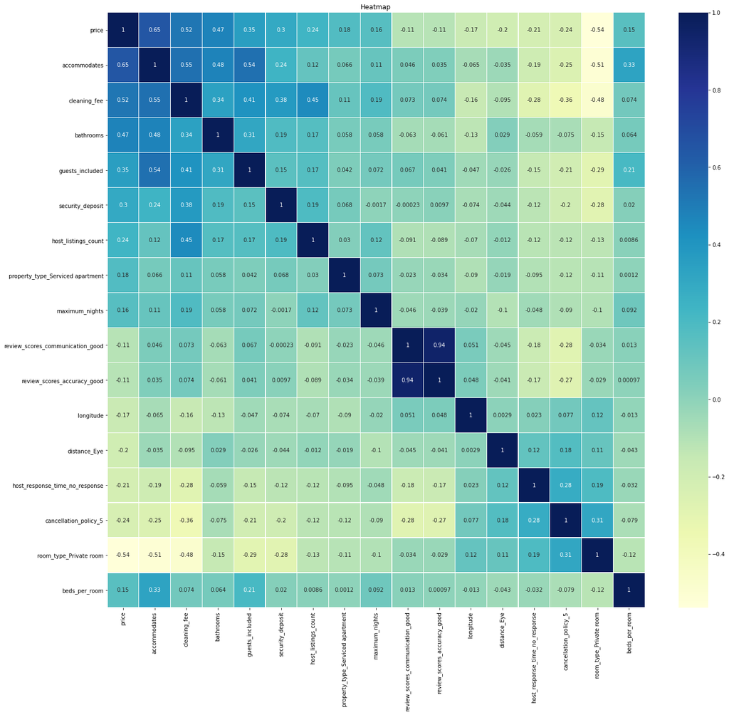

```python
colormap = plt.cm.RdBu
plt.figure(figsize = (22,20))
sns.heatmap(multi_selected_train.astype(float).corr(),linewidths = 0.2,annot = True,cmap="YlGnBu")
plt.title('Heatmap')
plt.show()
```

Descriptive Statictics:

```python
skew = multi_selected_train.skew()
kurt = multi_selected_train.kurt()
describe_train = multi_selected_train.describe()
describe_train.loc['skew',:] = skew
describe_train.loc['kurt',:] = kurt
describe_train
```

|  | price | accommodates | cleaning_fee | bathrooms | guests_included | security_deposit | host_listings_count | property_type_Serviced apartment | maximum_nights | review_scores_communication_good | review_scores_accuracy_good | longitude | distance_Eye | host_response_time_no_response | cancellation_policy_5 | room_type_Private room | beds_per_room |
| --- | --- | --- | --- | --- | --- | --- | --- | --- | --- | --- | --- | --- | --- | --- | --- | --- | --- |
| count | 1000.000000 | 1000.000000 | 1000.000000 | 1000.000000 | 1000.000000 | 1000.000000 | 1000.000000 | 1000.000000 | 1000.000000 | 1000.000000 | 1000.000000 | 1000.000000 | 1000.000000 | 1000.000000 | 1000.000000 | 1000.000000 | 1000.000000 |
| mean | 103.997000 | 3.104000 | 31.674000 | 1.261000 | 1.534000 | 126.882000 | 28.254000 | 0.032000 | 715.375000 | 0.714000 | 0.709000 | -0.122576 | 5.247513 | 0.302000 | 0.333000 | 0.390000 | 1.152904 |
| std | 70.387623 | 1.786722 | 35.272225 | 0.508072 | 1.209259 | 242.748295 | 151.459359 | 0.176088 | 524.666911 | 0.452115 | 0.454451 | 0.066893 | 2.210828 | 0.459355 | 0.471522 | 0.487994 | 0.499784 |
| min | 25.000000 | 1.000000 | 0.000000 | 0.000000 | 1.000000 | 0.000000 | 1.000000 | 0.000000 | 1.000000 | 0.000000 | 0.000000 | -0.268728 | 0.000000 | 0.000000 | 0.000000 | 0.000000 | 0.000000 |
| 25% | 50.000000 | 2.000000 | 0.000000 | 1.000000 | 1.000000 | 0.000000 | 1.000000 | 0.000000 | 30.000000 | 0.000000 | 0.000000 | -0.181265 | 3.688127 | 0.000000 | 0.000000 | 0.000000 | 1.000000 |
| 50% | 85.000000 | 2.000000 | 22.000000 | 1.000000 | 1.000000 | 0.000000 | 1.000000 | 0.000000 | 1125.000000 | 1.000000 | 1.000000 | -0.121635 | 5.135091 | 0.000000 | 0.000000 | 0.000000 | 1.000000 |
| 75% | 135.000000 | 4.000000 | 50.000000 | 1.500000 | 2.000000 | 200.000000 | 4.000000 | 0.000000 | 1125.000000 | 1.000000 | 1.000000 | -0.070426 | 6.698997 | 1.000000 | 1.000000 | 1.000000 | 1.000000 |
| max | 400.000000 | 13.000000 | 300.000000 | 4.000000 | 11.000000 | 3788.000000 | 1277.000000 | 1.000000 | 1125.000000 | 1.000000 | 1.000000 | 0.031913 | 11.762300 | 1.000000 | 1.000000 | 1.000000 | 6.000000 |
| skew | 1.645467 | 1.397247 | 1.862883 | 1.721113 | 3.320158 | 5.752068 | 7.811469 | 5.326174 | -0.517556 | -0.948558 | -0.921635 | 0.116462 | 0.289848 | 0.863806 | 0.709763 | 0.451729 | 2.707468 |
| kurt | 3.113210 | 2.539075 | 6.246177 | 3.277915 | 14.151245 | 63.472841 | 61.172735 | 26.420972 | -1.715451 | -1.102447 | -1.152899 | -0.798413 | -0.236116 | -1.256356 | -1.499238 | -1.799544 | 15.770238 |

Distribution of $y$ and $x$:

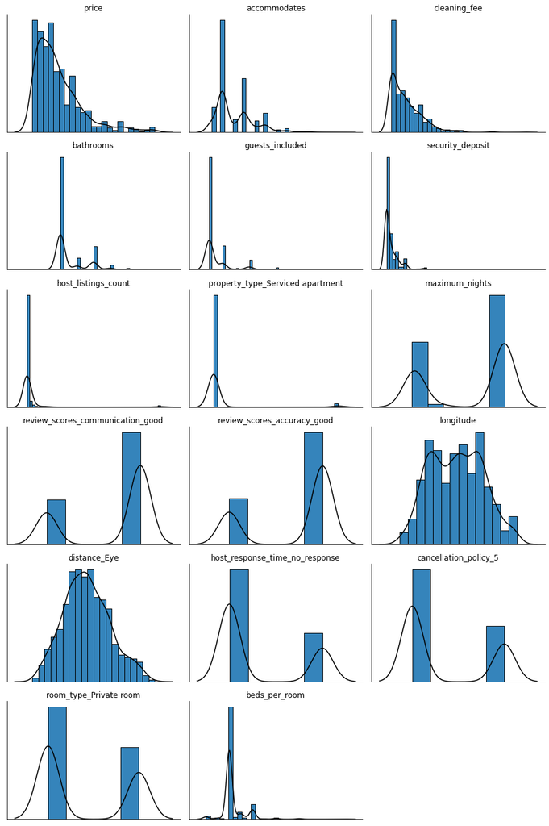

```python
from statlearning01 import plot_histograms
plot_histograms(multi_selected_train)
plt.show()
```

# Data transformation

Log transformation:

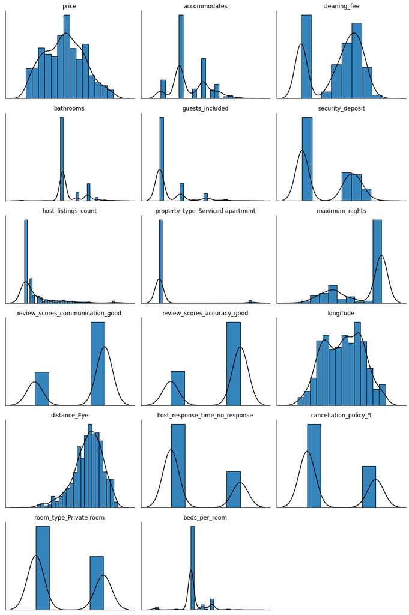

```python
# Check the distribution of variables after log transformation
plot_histograms(np.log1p(multi_selected_train))
plt.show()
```

```python
# log1p
X_train_log1p = np.log1p(multi_selected_train.iloc[:,1:])
y_train_log1p = np.log1p(multi_selected_train.iloc[:,0])
X_test_log1p = np.log1p(multi_selected_test.iloc[:,1:])
```

Standardization

```python
# Standardize
scaler = StandardScaler()
scaler.fit(X_train_log1p)
scaler.fit(X_test_log1p)
X_train_log1p_scaled = scaler.transform(X_train_log1p)
X_test_log1p_scaled = scaler.transform(X_test_log1p)
```

```python
from sklearn.model_selection import train_test_split
X_train, X_valid, y_train, y_valid = train_test_split(X_train_log1p, y_train_log1p, test_size=0.2)
```

```python
X_train_scaled, X_valid_scaled, y_train_scaled, y_valid_scaled = train_test_split(X_train_log1p_scaled, y_train_log1p, test_size=0.2)
```

# Model Training

OLS

```python
# OLS
OLS_model = LinearRegression(fit_intercept=True)
OLS_model.fit(X_train_log1p,y_train_log1p)
trainPredict_OLS=OLS_model.predict(X_train)
testPredict_OLS=OLS_model.predict(X_valid)
trainScore_OLS = math.sqrt(mean_squared_error(np.exp(y_train)-1, np.exp(trainPredict_OLS)-1))
print('OLS Train Score: %.3f RMSE' % (trainScore_OLS))
testScore_OLS = math.sqrt(mean_squared_error(np.exp(y_valid)-1, np.exp(testPredict_OLS)-1))
print('OLS Validation Score: %.3f RMSE' % (testScore_OLS))
```

```
OLS Train Score: 44.941 RMSE
OLS Validation Score: 41.189 RMSE
```

```
(<Figure size 432x288 with 1 Axes>,
 <AxesSubplot:title={'center':'Estimated coefficients'}>)
```

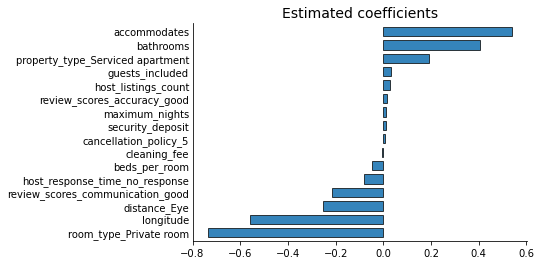

```python
from statlearning01 import plot_coefficients
plot_coefficients(OLS_model,X_train_log1p.columns)
```

```python
OLS_model_sm = sm.OLS(y_train_log1p,sm.add_constant(X_train_log1p_scaled)).fit()
print(OLS_model_sm.summary())
```

```
                            OLS Regression Results
==============================================================================
Dep. Variable:                  price   R-squared:                       0.664
Model:                            OLS   Adj. R-squared:                  0.659
Method:                 Least Squares   F-statistic:                     121.6
Date:                Sat, 20 Feb 2021   Prob (F-statistic):          7.68e-220
Time:                        09:44:42   Log-Likelihood:                -392.48
No. Observations:                1000   AIC:                             819.0
Df Residuals:                     983   BIC:                             902.4
Df Model:                          16
Covariance Type:            nonrobust
==============================================================================
                 coef    std err          t      P>|t|      [0.025      0.975]
------------------------------------------------------------------------------
const          4.4999      0.012    385.653      0.000       4.477       4.523
x1             0.2171      0.017     12.451      0.000       0.183       0.251
x2            -0.0105      0.016     -0.668      0.504      -0.042       0.020
x3             0.0824      0.013      6.250      0.000       0.057       0.108
x4             0.0112      0.014      0.775      0.438      -0.017       0.040
x5             0.0277      0.014      2.020      0.044       0.001       0.055
x6             0.0402      0.015      2.733      0.006       0.011       0.069
x7             0.0232      0.012      2.008      0.045       0.001       0.046
x8             0.0217      0.011      1.898      0.058      -0.001       0.044
x9            -0.0659      0.035     -1.910      0.056      -0.134       0.002
x10            0.0042      0.035      0.123      0.902      -0.063       0.072
x11           -0.0426      0.012     -3.625      0.000      -0.066      -0.020
x12           -0.1038      0.012     -8.493      0.000      -0.128      -0.080
x13           -0.0257      0.013     -1.963      0.050      -0.051    -1.3e-05
x14            0.0017      0.013      0.134      0.894      -0.024       0.027
x15           -0.2474      0.015    -16.838      0.000      -0.276      -0.219
x16           -0.0092      0.012     -0.768      0.443      -0.033       0.014
==============================================================================
Omnibus:                       68.972   Durbin-Watson:                   2.042
Prob(Omnibus):                  0.000   Jarque-Bera (JB):              108.936
Skew:                           0.524   Prob(JB):                     2.21e-24
Kurtosis:                       4.232   Cond. No.                         7.97
==============================================================================

Notes:
[1] Standard Errors assume that the covariance matrix of the errors is correctly specified.
```

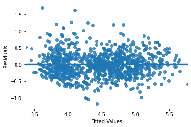

```python
# scatter plot
fig, ax = plt.subplots()
sns.regplot(OLS_model_sm.fittedvalues,OLS_model_sm.resid)
ax.set_ylabel('Residuals')
ax.set_xlabel('Fitted Values')
sns.despine()
plt.show()
```

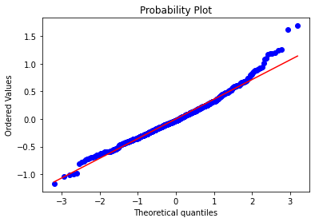

```python
# Normal Probability Plot
fig = plt.figure()
stats.probplot(OLS_model_sm.resid, dist="norm", plot=plt)
plt.show()
```

```python
predicted = cross_val_predict(OLS_model,X_train_log1p,y_train_log1p,cv=5)
OLS_log1p_rmse = np.sqrt(mean_squared_error(y_train_log1p,predicted))
OLS_rmse = np.sqrt(mean_squared_error(np.exp(y_train_log1p)-1,np.exp(predicted)))
print('OLS_log1p_rmse: ',OLS_log1p_rmse)
print('OLS_rmse: ',OLS_rmse)
```

```
OLS_log1p_rmse:  0.3637053556442507
OLS_rmse:  44.58065310733304
```

Ridge

```python
# Ridge
alphas = list(np.logspace(-15, 15, 151, base=2))
Ridge_model =Pipeline((
    ('scaler', StandardScaler()), #task 1 standardisation
    ('estimator', RidgeCV(alphas=alphas, cv=5)), #task 2, fit ridge regression
))

Ridge_model.fit(X_train_log1p, y_train_log1p)
```

```
Pipeline(steps=[('scaler', StandardScaler()),
                ('estimator',
                 RidgeCV(alphas=array([3.05175781e-05, 3.50554918e-05, 4.02681858e-05, 4.62559987e-05,
       5.31341897e-05, 6.10351562e-05, 7.01109836e-05, 8.05363715e-05,
       9.25119975e-05, 1.06268379e-04, 1.22070312e-04, 1.40221967e-04,
       1.61072743e-04, 1.85023995e-04, 2.12536759e-04, 2.44140625e-04,
       2.80443934e-04, 3.22145486e-04, 3...
       1.55209376e+03, 1.78288755e+03, 2.04800000e+03, 2.35253423e+03,
       2.70235220e+03, 3.10418753e+03, 3.56577511e+03, 4.09600000e+03,
       4.70506846e+03, 5.40470440e+03, 6.20837506e+03, 7.13155021e+03,
       8.19200000e+03, 9.41013692e+03, 1.08094088e+04, 1.24167501e+04,
       1.42631004e+04, 1.63840000e+04, 1.88202738e+04, 2.16188176e+04,
       2.48335002e+04, 2.85262009e+04, 3.27680000e+04]),
                         cv=5))])
```

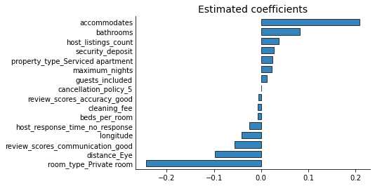

```python
def plot_coefficients(model, labels):
    coef = model.coef_
    table = pd.Series(coef.ravel(), index = labels).sort_values(ascending=True, inplace=False)

    all_ = True
    if len(table) > 20:
        reference = pd.Series(np.abs(coef.ravel()), index = labels).sort_values(ascending=False, inplace=False)
        reference = reference.iloc[:20]
        table = table[reference.index]
        table = table.sort_values(ascending=True, inplace=False)
        all_ = False


    fig, ax = fig, ax = plt.subplots()
    table.T.plot(kind='barh', edgecolor='black', width=0.7, linewidth=.8, alpha=0.9, ax=ax)
    ax.tick_params(axis=u'y', length=0)
    if all_:
        ax.set_title('Estimated coefficients', fontsize=14)
    else:
        ax.set_title('Estimated coefficients (twenty largest in absolute value)', fontsize=14)
    sns.despine()
    return fig, ax
plot_coefficients(Ridge_model._final_estimator,X_train_log1p.columns)
plt.show()
```

```python
trainPredict_Ridge=Ridge_model.predict(X_train)
testPredict_Ridge=Ridge_model.predict(X_valid)
trainScore_Ridge = math.sqrt(mean_squared_error(np.exp(y_train)-1, np.exp(trainPredict_Ridge)-1))
print('Ridge Train Score: %.3f RMSE' % (trainScore_Ridge))
testScore_Ridge = math.sqrt(mean_squared_error(np.exp(y_valid)-1, np.exp(testPredict_Ridge)-1))
print('Ridge Validation Score: %.3f RMSE' % (testScore_Ridge))
```

```
Ridge Train Score: 45.070 RMSE
Ridge Validation Score: 41.461 RMSE
```

Lasso

```python
# LASSO
# LassoCV will automatically set alpha values and crossvalidate them
Lasso_model =Pipeline((
    ('scaler', StandardScaler()),
    ('estimator', LassoCV(alphas=alphas, cv=5)),
))

Lasso_model=Lasso_model.fit(X_train, y_train)
```

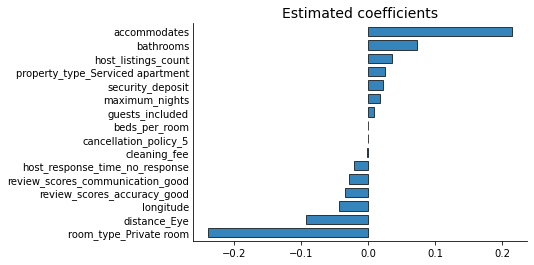

```python
plot_coefficients(Lasso_model._final_estimator,X_train_log1p.columns)
plt.show()
```

```python
trainPredict_lasso=Lasso_model.predict(X_train)
testPredict_lasso=Lasso_model.predict(X_valid)
trainScore_lasso = math.sqrt(mean_squared_error(np.exp(y_train)-1, np.exp(trainPredict_lasso)-1))
print('Train Score: %.3f RMSE' % (trainScore_lasso))
testScore_lasso = math.sqrt(mean_squared_error(np.exp(y_valid)-1, np.exp(testPredict_lasso)-1))
print('Validation Score: %.3f RMSE' % (testScore_lasso))
```

```
Train Score: 45.210 RMSE
Validation Score: 42.182 RMSE
```

Elastic Net

```python
# Elastic Net
Enet_model = Pipeline((
    ('scaler', StandardScaler()),
    ('estimator', ElasticNetCV(l1_ratio=[.01, .1, .2, .3, .4, .5, .6,.7,.8,.9])),
))

Enet_model=Enet_model.fit(X_train, y_train)
```

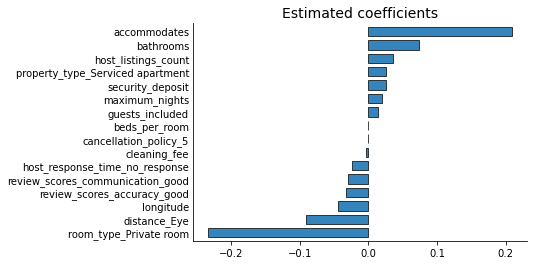

```python
plot_coefficients(Enet_model._final_estimator,X_train_log1p.columns)
plt.show()
```

```python
y_hat = Enet_model.predict(X_valid)
print ("Enet log1p RMSE:", np.sqrt(mean_squared_error(y_valid, y_hat)))
print ("Enet RMSE:", np.sqrt(mean_squared_error(np.exp(y_valid)-1,np.exp(y_hat))))
```

```
Enet log1p RMSE: 0.3255395938662365
Enet RMSE: 42.31748702105049
```

```python
trainPredict_Enet=Enet_model.predict(X_train)
testPredict_Enet=Enet_model.predict(X_valid)
trainScore_Enet = math.sqrt(mean_squared_error(np.exp(y_train)-1, np.exp(trainPredict_Enet)-1))
print('Train Score: %.3f RMSE' % (trainScore_Enet))
testScore_Enet = math.sqrt(mean_squared_error(np.exp(y_valid)-1, np.exp(testPredict_Enet)-1))
print('Validation Score: %.3f RMSE' % (testScore_Enet))
```

```
Train Score: 45.244 RMSE
Validation Score: 42.427 RMSE
```

KNN

```python
# KNN Regressor is more flexible than linear models and can model nonlinearity
# specify inputs
knn_model = KNeighborsRegressor()
tuning_parameters_dict = {'n_neighbors': np.arange(1, 51)}
num_folds = 5
scoring_metric = 'neg_mean_squared_error'

# initialize the grid search cross validation
knn_search = GridSearchCV(
    knn_model,
    tuning_parameters_dict,
    cv = num_folds,
    scoring = scoring_metric,
    return_train_score = False, # return the crossvalidation score for each parameter setting
    n_jobs = 4, # use multiple CPUs to run the crossvalidation
)
# run the grid search cross validation
knn_search.fit(X_train,y_train)
```

```
GridSearchCV(cv=5, estimator=KNeighborsRegressor(), n_jobs=4,
             param_grid={'n_neighbors': array([ 1,  2,  3,  4,  5,  6,  7,  8,  9, 10, 11, 12, 13, 14, 15, 16, 17,
       18, 19, 20, 21, 22, 23, 24, 25, 26, 27, 28, 29, 30, 31, 32, 33, 34,
       35, 36, 37, 38, 39, 40, 41, 42, 43, 44, 45, 46, 47, 48, 49, 50])},
             scoring='neg_mean_squared_error')
```

```python
# extract the best KNN model
knn_best_model = knn_search.best_estimator_
knn_search.best_params_
```

```
{'n_neighbors': 5}
```

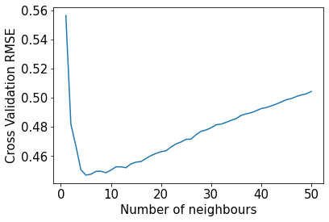

```
Lowest CV error: K = 5
```

```python
# calculating the RMSE for each 𝑘
neighbours = np.arange(1, 51)
cv_rmse = []

for k in neighbours:
    model = KNeighborsRegressor(n_neighbors = k)
    scores = cross_val_score(
        model, X_train, y_train,
        cv=5, scoring = 'neg_mean_squared_error'
    )
    rmse = np.sqrt(-1*np.mean(scores))
    cv_rmse.append(rmse)

# plot the RMSE
fig, ax = plt.subplots()
ax.plot(neighbours, cv_rmse)
ax.set_xlabel('Number of neighbours', fontsize = 15)
ax.set_ylabel('Cross Validation RMSE', fontsize = 15)
plt.xticks(fontsize = 15)
plt.yticks(fontsize = 15)
plt.show()

print(f'Lowest CV error: K = {1 + np.argmin(cv_rmse)}')
```

```python
# train & test RMSE
trainPredict_knn=knn_best_model.predict(X_train)
testPredict_knn=knn_best_model.predict(X_valid)
trainScore_knn = math.sqrt(mean_squared_error(np.exp(y_train)-1, np.exp(trainPredict_knn)-1))
print('Train Score: %.3f RMSE' % (trainScore_knn))
testScore_knn = math.sqrt(mean_squared_error(np.exp(y_valid)-1, np.exp(testPredict_knn)-1))
print('Validation Score: %.3f RMSE' % (testScore_knn))
```

```
Train Score: 48.078 RMSE
Validation Score: 48.395 RMSE
```

Decision Tree

```python
Tree_model = DecisionTreeRegressor()
tuning_parameters = {
    'max_depth':[1,5,10,12],
    'min_samples_leaf':np.arange(1,30),
}
Tree = GridSearchCV(Tree_model, tuning_parameters,cv = 5, return_train_score=False, n_jobs=4)
Tree.fit(X_train, y_train)
Tree_opitimal = Tree.best_estimator_
print('Tree Parameters: ',Tree.best_params_)
```

```
Tree Parameters:  {'max_depth': 5, 'min_samples_leaf': 21}
```

```python
# Visualizing the best estimator decision tree
import graphviz
from sklearn.tree import export_graphviz
predictors=list(X_train.columns.values)
dot_data = export_graphviz(
    Tree_opitimal,
    out_file = None,
    feature_names = predictors,
    impurity = True,
    rounded = True
)
graph = graphviz.Source(dot_data)
graph.format = 'png'
graph.render('regression-tree')
graph
```

[figure not shown]

```python
Tree_model = DecisionTreeRegressor(max_depth=5, min_samples_leaf=24)
Tree_model = Tree_model.fit(X_train, y_train)
trainPredict_Tree=Tree_model.predict(X_train)
testPredict_Tree=Tree_model.predict(X_valid)
trainScore_Tree = math.sqrt(mean_squared_error(np.exp(y_train)-1, np.exp(trainPredict_Tree)-1))
print('Train Score: %.3f RMSE' % (trainScore_Tree))
testScore_Tree = math.sqrt(mean_squared_error(np.exp(y_valid)-1, np.exp(testPredict_Tree)-1))
print('Validation Score: %.3f RMSE' % (testScore_Tree))
```

```
Train Score: 44.927 RMSE
Validation Score: 43.006 RMSE
```

```python
# bagging
bag = BaggingRegressor()
param_grid = {'n_estimators': np.arange(1,200,10)}
bag_search =  GridSearchCV(bag, param_grid, cv=5,  scoring = 'neg_mean_squared_error', return_train_score=False, n_jobs=4)
bag_search.fit(X_train, y_train)
bag_search.best_params_
```

```
{'n_estimators': 141}
```

```python
bag = BaggingRegressor(n_estimators=141, random_state=42)
bag.fit(X_train, y_train)

trainPredict_bag=bag.predict(X_train)
testPredict_bag=bag.predict(X_valid)

trainScore_bag = math.sqrt(mean_squared_error(np.exp(y_train)-1, np.exp(trainPredict_bag)-1))
print('Train Score: %.3f RMSE' % (trainScore_bag))
testScore_bag = math.sqrt(mean_squared_error(np.exp(y_valid)-1, np.exp(testPredict_bag)-1))
print('Validation Score: %.3f RMSE' % (testScore_bag))
```

```
Train Score: 19.718 RMSE
Validation Score: 39.326 RMSE
```

```python
# Random Forest
RF_model = RandomForestRegressor()
tuning_parameters = {
    'max_features': np.arange(1,len(X_train_log1p.columns)),
    'min_samples_leaf': [5, 10, 20],
    'n_estimators' : [200,400]
}
RF_bst = GridSearchCV(RF_model, tuning_parameters, cv = 10, return_train_score=False, n_jobs=4)
RF_bst.fit(X_train_log1p, y_train_log1p)
RF = RF_bst.best_estimator_
print('Best parameters found by RandomizedSearchCV:', RF_bst.best_params_, '\n')
```

```
Best parameters found by RandomizedSearchCV: {'max_features': 6, 'min_samples_leaf': 5, 'n_estimators': 400}
```

```python
RF_model = RandomForestRegressor(n_estimators=400, min_samples_leaf=5, max_features=6,random_state=42)
RF_model = RF_model.fit(X_train, y_train)

trainPredict_RF=RF_model.predict(X_train)
testPredict_RF=RF_model.predict(X_valid)

trainScore_RF = math.sqrt(mean_squared_error(np.exp(y_train)-1, np.exp(trainPredict_RF)-1))
print('Train Score: %.3f RMSE' % (trainScore_RF))
testScore_RF = math.sqrt(mean_squared_error(np.exp(y_valid)-1, np.exp(testPredict_RF)-1))
print('Validation Score: %.3f RMSE' % (testScore_RF))
```

```
Train Score: 36.945 RMSE
Validation Score: 39.855 RMSE
```

```python
def plot_feature_importance(model, labels, max_features = 20):
    feature_importance = model.feature_importances_*100
    feature_importance = 100*(feature_importance/np.max(feature_importance))
    table = pd.Series(feature_importance, index = labels).sort_values(ascending=True, inplace=False)
    fig, ax = fig, ax = plt.subplots(figsize=(9,6))
    if len(table) > max_features:
        table.iloc[-max_features:].T.plot(kind='barh', edgecolor='black', width=0.7, linewidth=.8, alpha=0.9, ax=ax)
    else:
        table.T.plot(kind='barh', edgecolor='black', width=0.7, linewidth=.8, alpha=0.9, ax=ax)
    ax.tick_params(axis=u'y', length=0)
    ax.set_title('Variable importance', fontsize=13)
    sns.despine()
    return fig, ax
```

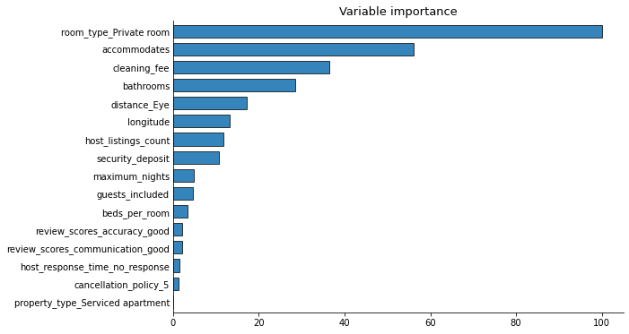

```python
plot_feature_importance(RF_model, X_train_log1p.columns)
plt.show()
```

```
model_xgb = xgb.XGBRegressor()
tuning_parameters = {
    'max_depth': range(3, 10, 1),
    'min_child_weight': range(1, 10, 2),
    'learning_rate': [0.01, 0.05, 0.1],
    'n_estimators' : [250, 500, 750, 1000, 1500, 2000],
    'subsample' : [0.6, 0.8, 1.0]
}

bst = GridSearchCV(model_xgb, tuning_parameters, cv = 10, return_train_score=False, n_jobs=4)
bst.fit(X_train_log1p, y_train_log1p)

print('Best parameters found by GridSearchCV:', bst.best_params_, '\n')
```

```python
model_xgb = xgb.XGBRegressor(reg_lambda=0, learning_rate=0.01, max_depth=2, min_child_weight=2, n_estimators=1000, subsample=0.5)
model_xgb=model_xgb.fit(X_train, y_train)
trainPredict_xgb=model_xgb.predict(X_train)
testPredict_xgb=model_xgb.predict(X_valid)

trainScore_xgb = math.sqrt(mean_squared_error(np.exp(y_train)-1, np.exp(trainPredict_xgb)-1))
print('Train Score: %.3f RMSE' % (trainScore_xgb))
testScore_xgb = math.sqrt(mean_squared_error(np.exp(y_valid)-1, np.exp(testPredict_xgb)-1))
print('Validation Score: %.3f RMSE' % (testScore_xgb))
```

```
Train Score: 36.510 RMSE
Validation Score: 38.521 RMSE
```

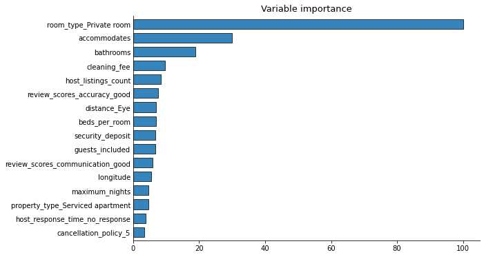

```python
plot_feature_importance(model_xgb, X_train_log1p.columns)
plt.show()
```

```python
#L GBM
from lightgbm import LGBMRegressor,LGBMClassifier
import lightgbm as lgb
```

```python
model_lgb = lgb.LGBMRegressor()
tuning_parameters = {
    'learning_rate': [0.01, 0.05, 0.1],
    'n_estimators' : [250, 500, 750, 1000, 1500, 2000],
    'max_depth' : [2,3,4],
    'subsample' : [0.6, 0.8, 1.0]
}

lbst = RandomizedSearchCV(model_lgb, tuning_parameters, n_iter = 20, cv = 10, return_train_score=False, n_jobs=4)
lbst.fit(X_train, y_train)

print('Best parameters found by randomised search:', lbst.best_params_, '\n')
```

```
Best parameters found by randomised search: {'subsample': 1.0, 'n_estimators': 1000, 'max_depth': 2, 'learning_rate': 0.01}
```

```python
model_lgb = lgb.LGBMRegressor(reg_lambda=3,n_estimators=250, max_depth=3, learning_rate=0.05,min_child_weight=7,subsample=1)
model_lgb=model_lgb.fit(X_train, y_train)
```

```python
trainPredict_lgb=model_lgb.predict(X_train)
testPredict_lgb=model_lgb.predict(X_valid)

trainScore_lgb = math.sqrt(mean_squared_error(np.exp(y_train)-1, np.exp(trainPredict_lgb)-1))
print('Train Score: %.3f RMSE' % (trainScore_lgb))
testScore_lgb = math.sqrt(mean_squared_error(np.exp(y_valid)-1, np.exp(testPredict_lgb)-1))
print('Validation Score: %.3f RMSE' % (testScore_lgb))
```

```
Train Score: 33.957 RMSE
Validation Score: 38.586 RMSE
```

```python
# Model Stacking
models = [OLS_model,Lasso_model,Ridge_model,Enet_model,RF_model,model_xgb,model_lgb]

stack = StackingCVRegressor(models, meta_regressor = LinearRegression(), cv=10)
stack.fit(X_train, y_train)
```

```
StackingCVRegressor(cv=10, meta_regressor=LinearRegression(),
                    regressors=[LinearRegression(),
                                Pipeline(steps=[('scaler', StandardScaler()),
                                                ('estimator',
                                                 LassoCV(alphas=[3.0517578125e-05,
                                                                 3.505549179068098e-05,
                                                                 4.026818575356734e-05,
                                                                 4.625599873383782e-05,
                                                                 5.313418965430448e-05,
                                                                 6.103515625e-05,
                                                                 7.011098358136196e-05,
                                                                 8.053637150713468e-05,
                                                                 9.251199746767564e-05...
                                             max_delta_step=0, max_depth=2,
                                             min_child_weight=2, missing=nan,
                                             monotone_constraints='()',
                                             n_estimators=1000, n_jobs=8,
                                             num_parallel_tree=1,
                                             random_state=0, reg_alpha=0,
                                             reg_lambda=0, scale_pos_weight=1,
                                             subsample=0.5, tree_method='exact',
                                             validate_parameters=1,
                                             verbosity=None),
                                LGBMRegressor(learning_rate=0.05, max_depth=3,
                                              min_child_weight=7,
                                              n_estimators=250, reg_lambda=3,
                                              subsample=1)])
```

# Prediction and Submission

```python
output=stack.predict(pd.DataFrame(X_test_log1p))
output=np.exp(output)-1
test_output = test.copy()
test_output['price'] = output
test_output[['price']].to_csv('test10.csv',index=None)
```

```python
# Submit
output=model_xgb.predict(X_test_log1p)
output=np.exp(output)-1
test_output = test.copy()
test_output['price'] = output
test_output[['price']].to_csv('test11.csv',index=None)
```

```python
# Submit
output=model_xgb.predict(X_test_log1p)
output=np.exp(output)-1
test_output = test.copy()
test_output['price'] = output
test_output[['price']].to_csv('test12.csv',index=None)
```

```python
model_xgb1=model_xgb.fit(X_train_log1p, y_train_log1p)
output=model_xgb1.predict(X_test_log1p)
output=np.exp(output)-1
test_output = test.copy()
test_output['price'] = output
test_output[['price']].to_csv('test13.csv',index=None)
```